# Getting Started with healthyR.ai

A Quick Introduction

Steven P. Sanderson II, MPH

2025-04-22

First of all, thank you for using `healthyR.ai`. If you encounter issues or want to make a feature request, please visit https://github.com/spsanderson/healthyR.ai/issues

```r
library(healthyR.ai)
```

In this should example we will showcase the `pca_your_recipe()` function. This function takes only a few arguments. The arguments are currently `.data` which is the full data set that gets passed internally to the `recipes::bake()` function, `.recipe_object` which is a recipe you have already made and want to pass to the function in order to perform the pca, and finally `.threshold` which is the fraction of the variance that should be captured by the components.

To start this walk through we will first load in a few libraries.

# Libraries

```r
library(timetk)
library(dplyr)
library(purrr)
library(healthyR.data)
library(rsample)
library(recipes)
library(ggplot2)
library(plotly)
```

# Data

Now that we have out libraries we can go ahead and get our data set ready.

## Data Set

```r
data_tbl <- healthyR_data %>%
    select(visit_end_date_time) %>%
    summarise_by_time(
        .date_var = visit_end_date_time,
        .by       = "month",
        value     = n()
    ) %>%
    set_names("date_col","value") %>%
    filter_by_time(
        .date_var = date_col,
        .start_date = "2013",
        .end_date = "2020"
    ) %>%
    mutate(date_col = as.Date(date_col))

head(data_tbl)
```

```
#> # A tibble: 6 × 2
#>   date_col   value
#>   <date>     <int>
#> 1 2013-01-01  2082
#> 2 2013-02-01  1719
#> 3 2013-03-01  1796
#> 4 2013-04-01  1865
#> 5 2013-05-01  2028
#> 6 2013-06-01  1813
```

The data set is simple and by itself would not be at all useful for a pca analysis since there is only one predictor, being time. In order to facilitate the use of the function and this example, we will create a `splits` object and a `recipe` object.

## Splits

```r
splits <- initial_split(data = data_tbl, prop = 0.8)

splits
```

```
#> <Training/Testing/Total>
#> <76/19/95>
```

```r
head(training(splits))
```

```
#> # A tibble: 6 × 2
#>   date_col   value
#>   <date>     <int>
#> 1 2019-10-01  1525
#> 2 2014-12-01  1757
#> 3 2017-08-01  1607
#> 4 2019-07-01  1474
#> 5 2020-07-01  1056
#> 6 2013-03-01  1796
```

## Initial Recipe

```r
rec_obj <- recipe(value ~ ., training(splits)) %>%
    step_timeseries_signature(date_col) %>%
    step_rm(matches("(iso$)|(xts$)|(hour)|(min)|(sec)|(am.pm)"))

rec_obj
```

```
#>
#> ── Recipe ──────────────────────────────────────────────────────────────────────
#>
#> ── Inputs
#> Number of variables by role
#> outcome:   1
#> predictor: 1
#>
#> ── Operations
#> • Timeseries signature features from: date_col
#> • Variables removed: matches("(iso$)|(xts$)|(hour)|(min)|(sec)|(am.pm)")
```

```r
get_juiced_data(rec_obj) %>% glimpse()
```

```
#> Rows: 76
#> Columns: 20
#> $ date_col           <date> 2019-10-01, 2014-12-01, 2017-08-01, 2019-07-01, 20…
#> $ value              <int> 1525, 1757, 1607, 1474, 1056, 1796, 1628, 1651, 130…
#> $ date_col_index.num <dbl> 1569888000, 1417392000, 1501545600, 1561939200, 159…
#> $ date_col_year      <int> 2019, 2014, 2017, 2019, 2020, 2013, 2015, 2018, 201…
#> $ date_col_half      <int> 2, 2, 2, 2, 2, 1, 1, 2, 2, 2, 2, 1, 1, 1, 2, 2, 2, …
#> $ date_col_quarter   <int> 4, 4, 3, 3, 3, 1, 1, 3, 4, 3, 4, 2, 2, 2, 4, 3, 4, …
#> $ date_col_month     <int> 10, 12, 8, 7, 7, 3, 3, 7, 11, 7, 10, 5, 5, 4, 12, 9…
#> $ date_col_month.lbl <ord> October, December, August, July, July, March, March…
#> $ date_col_day       <int> 1, 1, 1, 1, 1, 1, 1, 1, 1, 1, 1, 1, 1, 1, 1, 1, 1, …
#> $ date_col_wday      <int> 3, 2, 3, 2, 4, 6, 1, 1, 6, 3, 7, 4, 6, 2, 7, 2, 5, …
#> $ date_col_wday.lbl  <ord> Tuesday, Monday, Tuesday, Monday, Wednesday, Friday…
#> $ date_col_mday      <int> 1, 1, 1, 1, 1, 1, 1, 1, 1, 1, 1, 1, 1, 1, 1, 1, 1, …
#> $ date_col_qday      <int> 1, 62, 32, 1, 1, 60, 60, 1, 32, 1, 1, 31, 31, 1, 62…
#> $ date_col_yday      <int> 274, 335, 213, 182, 183, 60, 60, 182, 305, 182, 275…
#> $ date_col_mweek     <int> 5, 6, 6, 6, 5, 5, 4, 5, 5, 5, 5, 5, 5, 6, 5, 6, 5, …
#> $ date_col_week      <int> 40, 48, 31, 26, 27, 9, 9, 26, 44, 26, 40, 18, 18, 1…
#> $ date_col_week2     <int> 0, 0, 1, 0, 1, 1, 1, 0, 0, 0, 0, 0, 0, 1, 0, 1, 0, …
#> $ date_col_week3     <int> 1, 0, 1, 2, 0, 0, 0, 2, 2, 2, 1, 0, 0, 1, 0, 2, 1, …
#> $ date_col_week4     <int> 0, 0, 3, 2, 3, 1, 1, 2, 0, 2, 0, 2, 2, 1, 0, 3, 0, …
#> $ date_col_mday7     <int> 1, 1, 1, 1, 1, 1, 1, 1, 1, 1, 1, 1, 1, 1, 1, 1, 1, …
```

Now that we have out initial recipe we can use the `pca_your_recipe()` function.

```r
pca_list <- pca_your_recipe(
  .recipe_object = rec_obj,
  .data          = data_tbl,
  .threshold     = 0.8,
  .top_n         = 5
)
```

# Inspect PCA Output

The function returns a list object and does so `insvisible` so you must assign the output to a variable, you can then access the items of the list in the usual manner.

The following items are included in the output of the function:

1. pca_transform - This is the pca recipe.
2. variable_loadings
3. variable_variance
4. pca_estimates
5. pca_juiced_estimates
6. pca_baked_data
7. pca_variance_df
8. pca_variance_scree_plt
9. pca_rotation_df

Lets start going down the list of items.

## PCA Transform

This is the portion you will want to output to a variable as this is the recipe object itself that you will use further down the line of your work.

```r
pca_rec_obj <- pca_list$pca_transform

pca_rec_obj
```

```
#>
#> ── Recipe ──────────────────────────────────────────────────────────────────────
#>
#> ── Inputs
#> Number of variables by role
#> outcome:   1
#> predictor: 1
#>
#> ── Operations
#> • Timeseries signature features from: date_col
#> • Variables removed: matches("(iso$)|(xts$)|(hour)|(min)|(sec)|(am.pm)")
#> • Centering for: recipes::all_numeric()
#> • Scaling for: recipes::all_numeric()
#> • Sparse, unbalanced variable filter on: recipes::all_numeric()
#> • PCA extraction with: recipes::all_numeric_predictors()
```

## Variable Loadings

```r
pca_list$variable_loadings
```

```
#> # A tibble: 169 × 4
#>    terms                 value component id
#>    <chr>                 <dbl> <chr>     <chr>
#>  1 date_col_index.num -0.0665  PC1       pca_ZHMem
#>  2 date_col_year      -0.0124  PC1       pca_ZHMem
#>  3 date_col_half      -0.386   PC1       pca_ZHMem
#>  4 date_col_quarter   -0.433   PC1       pca_ZHMem
#>  5 date_col_month     -0.436   PC1       pca_ZHMem
#>  6 date_col_wday       0.0247  PC1       pca_ZHMem
#>  7 date_col_qday      -0.0497  PC1       pca_ZHMem
#>  8 date_col_yday      -0.436   PC1       pca_ZHMem
#>  9 date_col_mweek     -0.00376 PC1       pca_ZHMem
#> 10 date_col_week      -0.436   PC1       pca_ZHMem
#> # ℹ 159 more rows
```

## Variable Variance

```r
pca_list$variable_variance
```

```
#> # A tibble: 52 × 4
#>    terms       value component id
#>    <chr>       <dbl>     <int> <chr>
#>  1 variance 5.17             1 pca_ZHMem
#>  2 variance 2.03             2 pca_ZHMem
#>  3 variance 1.56             3 pca_ZHMem
#>  4 variance 1.28             4 pca_ZHMem
#>  5 variance 1.21             5 pca_ZHMem
#>  6 variance 0.638            6 pca_ZHMem
#>  7 variance 0.564            7 pca_ZHMem
#>  8 variance 0.488            8 pca_ZHMem
#>  9 variance 0.0581           9 pca_ZHMem
#> 10 variance 0.000227        10 pca_ZHMem
#> # ℹ 42 more rows
```

## PCA Estimates

```r
pca_list$pca_estimates
```

```
#>
#> ── Recipe ──────────────────────────────────────────────────────────────────────
#>
#> ── Inputs
#> Number of variables by role
#> outcome:   1
#> predictor: 1
#>
#> ── Training information
#> Training data contained 76 data points and no incomplete rows.
#>
#> ── Operations
#> • Timeseries signature features from: date_col | Trained
#> • Variables removed: date_col_year.iso date_col_month.xts, ... | Trained
#> • Centering for: value, date_col_index.num, date_col_year, ... | Trained
#> • Scaling for: value, date_col_index.num, date_col_year, ... | Trained
#> • Sparse, unbalanced variable filter removed: date_col_day, ... | Trained
#> • PCA extraction with: date_col_index.num date_col_year, ... | Trained
```

## Jucied and Baked Data

```r
pca_list$pca_juiced_estimates %>% glimpse()
```

```
#> Rows: 76
#> Columns: 9
#> $ date_col           <date> 2019-10-01, 2014-12-01, 2017-08-01, 2019-07-01, 20…
#> $ value              <dbl> -0.1102009, 0.7893652, 0.2077492, -0.3079504, -1.92…
#> $ date_col_month.lbl <ord> October, December, August, July, July, March, March…
#> $ date_col_wday.lbl  <ord> Tuesday, Monday, Tuesday, Monday, Wednesday, Friday…
#> $ PC1                <dbl> -2.7458635, -3.4270852, -0.7568537, -1.0440634, -0.…
#> $ PC2                <dbl> -1.565171740, 1.510429529, 0.204199388, -0.87311426…
#> $ PC3                <dbl> -0.0001972329, -0.6150954024, 2.3018101359, 2.76583…
#> $ PC4                <dbl> 1.74777239, -0.32725317, -1.11607242, 1.10893994, -…
#> $ PC5                <dbl> -0.07863831, -2.31569777, -0.53758842, -0.37896107,…
```

```r
pca_list$pca_baked_data %>% glimpse()
```

```
#> Rows: 95
#> Columns: 9
#> $ date_col           <date> 2013-01-01, 2013-02-01, 2013-03-01, 2013-04-01, 20…
#> $ value              <dbl> 2.0495332, 0.6420225, 0.9405853, 1.2081287, 1.84015…
#> $ date_col_month.lbl <ord> January, February, March, April, May, June, July, A…
#> $ date_col_wday.lbl  <ord> Tuesday, Friday, Friday, Monday, Wednesday, Saturda…
#> $ PC1                <dbl> 3.4030132, 2.9907161, 2.6285260, 1.9099228, 1.07026…
#> $ PC2                <dbl> 2.2966037, 1.9992129, 1.5477109, 2.3559201, 1.55679…
#> $ PC3                <dbl> 0.6290209, -0.6557058, -2.1183589, 0.7861542, -1.58…
#> $ PC4                <dbl> 1.2683326, 0.2364059, -1.0048467, 1.1701121, -0.161…
#> $ PC5                <dbl> -0.88429703, 1.47350272, -0.05630354, -1.20416386, …
```

## Roatation Data

```r
pca_list$pca_rotation_df %>% glimpse()
```

```
#> Rows: 13
#> Columns: 13
#> $ PC1  <dbl> -0.066493201, -0.012379375, -0.386498673, -0.433405887, -0.435723…
#> $ PC2  <dbl> -0.674160359, -0.681686543, 0.075236177, 0.028032622, 0.024532164…
#> $ PC3  <dbl> 0.18192975, 0.18480670, 0.21781743, 0.04525416, -0.01460549, -0.2…
#> $ PC4  <dbl> -0.006537556, 0.005703034, 0.003132411, 0.088662408, -0.098568289…
#> $ PC5  <dbl> -0.007972229, -0.007170887, 0.154342827, 0.031146186, -0.00861421…
#> $ PC6  <dbl> -0.02622017, -0.02367719, -0.26195169, -0.01115824, -0.01983138, …
#> $ PC7  <dbl> -0.03150548, -0.02642184, -0.11599004, -0.03222366, -0.03972107, …
#> $ PC8  <dbl> -0.0610268588, -0.0608669252, 0.2228511579, 0.1218330341, -0.0003…
#> $ PC9  <dbl> -0.01279068, 0.01449010, 0.80120634, -0.27505382, -0.21482529, 0.…
#> $ PC10 <dbl> 0.014209863, -0.012122646, -0.001798115, 0.300512705, 0.373009670…
#> $ PC11 <dbl> -0.0259374659, 0.0265664980, -0.0015883283, -0.0391562630, 0.6626…
#> $ PC12 <dbl> -5.325697e-03, 5.040297e-03, -3.156335e-03, -7.847461e-01, 4.1619…
#> $ PC13 <dbl> -7.081036e-01, 7.034637e-01, 8.774929e-05, 3.414925e-02, 1.310318…
```

## Variance and Scree Plot

```r
pca_list$pca_variance_df %>% glimpse()
```

```
#> Rows: 13
#> Columns: 6
#> $ PC              <chr> "PC1", "PC2", "PC3", "PC4", "PC5", "PC6", "PC7", "PC8"…
#> $ var_explained   <dbl> 3.979029e-01, 1.561310e-01, 1.201252e-01, 9.838223e-02…
#> $ var_pct_txt     <chr> "39.79%", "15.61%", "12.01%", "9.84%", "9.29%", "4.91%…
#> $ cum_var_pct     <dbl> 0.3979029, 0.5540339, 0.6741591, 0.7725413, 0.8654737,…
#> $ cum_var_pct_txt <chr> "39.79%", "55.40%", "67.42%", "77.25%", "86.55%", "91.…
#> $ ou_threshold    <fct> Under, Under, Under, Under, Over, Over, Over, Over, Ov…
```

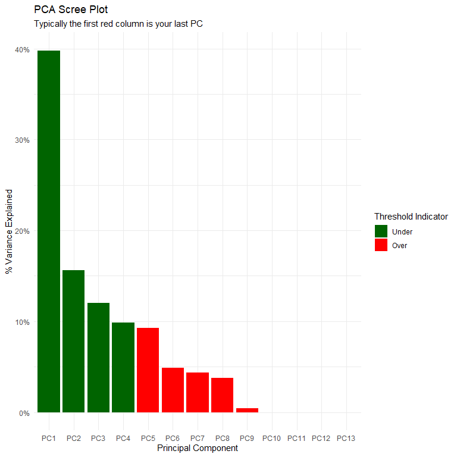

```r
pca_list$pca_variance_scree_plt
```

## Variable Loading Plots

[figure not shown]

```r
pca_list$pca_loadings_plt
```

[figure not shown]

```r
pca_list$pca_top_n_loadings_plt
```